# R Notebook

Here’s a glimpse of the raw data:

```r
head(sims)
```

| repetition | b | periods | memory | G | N | fixation_threshold | winner | generation | cor_prop_fit | cor_prop_reput | cor_reput_fit |
| --- | --- | --- | --- | --- | --- | --- | --- | --- | --- | --- | --- |
| 1 | 5 | 24 | 12 | 6 | 72 | 0.99 | S | 805 | 0.18668715 | 0.4339091 | 0.5155502 |
| 1 | 5 | 24 | 12 | 6 | 240 | 0.99 | S | 1353 | 0.06881432 | 0.3880650 | 0.4353189 |
| 1 | 5 | 24 | 12 | 12 | 72 | 0.99 | S | 299 | 0.09509397 | 0.5165100 | 0.6686335 |
| 1 | 5 | 24 | 12 | 12 | 240 | 0.99 | S | 1266 | 0.05796227 | 0.3708696 | 0.5078861 |
| 1 | 5 | 24 | 24 | 6 | 72 | 0.99 | S | 601 | 0.07414284 | 0.7306006 | 0.3631425 |
| 1 | 5 | 24 | 24 | 6 | 240 | 0.99 | S | 600 | 0.03823686 | 0.7786384 | 0.2794943 |

`repetition` is just the number of the simulation of a particular set of parameters, from 1-10. The next six columns are parameters: * `b` is the benefit of being helped; the cost was always 1. * `periods` is the number of periods in a generation. * `memory` is the length of GR types’ memory. - This was implemented as follows: individuals just remembered the last `memory` periods (not the last `memory` times they met somebody). For technical reasons that made things much quicker. * `G` is number of groups. * `N` is total population.

The simulation stopped when one strategy had 0.99 of the population (`fixation_threshold`).

The next columns are results. * `generation` says when the simulation stopped. * `winner` is which strategy went to fixation, GR or S. * `cor_prop_fit` is the correlation between group fitness, and the proportion of GR types. * `cor_prop_reput` is the correlation between group reputation, and the proportion of GR types. * `cor_reput_fit` is the correlation between group reputation, and group fitness.

The last three are averages over all generations (taken at the last period).

The data is also in the CSV file “sims.csv”.

# Basic facts

Here’s the parameters that were used:

```r
apply(sims[2:6], 2, unique)
```

```
      b periods memory  G   N
[1,]  5      24     12  6  72
[2,] 25      48     24 12 240
```

Selfish strategies mostly won:

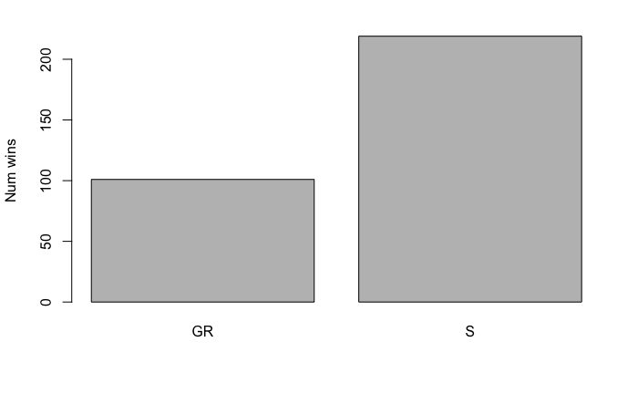

```r
barplot(table(sims$winner), ylab = "Num wins")
```

# Comparative statics

These graphs show the proportion of GR wins, for values of each individual parameter.

```
      b
Winner    5   25
    GR 0.08 0.56
    S  0.92 0.44
```

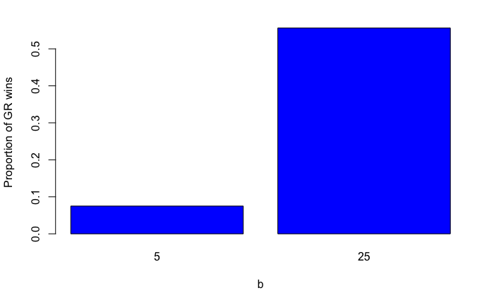

```r
show_wins <- function(param) {
  tbl <- table(sims$winner, sims[[param]], dnn = c("Winner", param)) %>% prop.table(2)
  print(round(tbl, 2))
  barplot(tbl[1,], col = c("blue"), ylab = "Proportion of GR wins", xlab = param)
}
show_wins("b")
```

```
      periods
Winner   24   48
    GR 0.30 0.33
    S  0.70 0.67
```

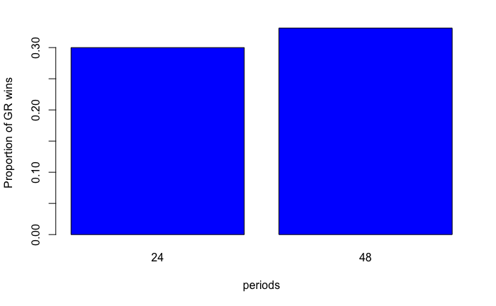

```r
show_wins("periods")
```

```
      memory
Winner   12   24
    GR 0.34 0.29
    S  0.66 0.71
```

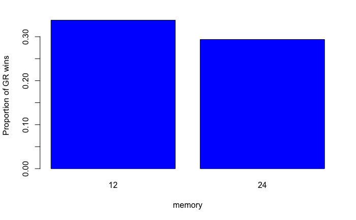

```r
show_wins("memory")
```

```
      G
Winner    6   12
    GR 0.19 0.44
    S  0.81 0.56
```

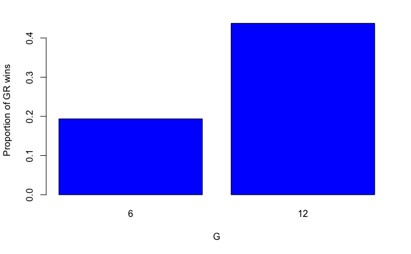

```r
show_wins("G")
```

```
      N
Winner   72  240
    GR 0.49 0.14
    S  0.51 0.86
```

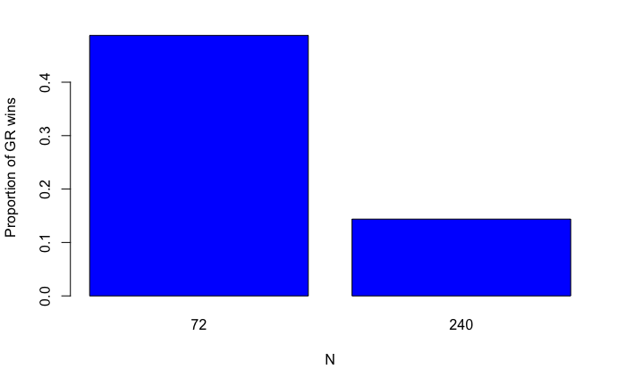

```r
show_wins("N")
```

Results are much as expected. Higher b, smaller groups, smaller population all lead to more GR wins. Number of periods seems not to matter much; oddly, long memory seems to have made things worse for GR.

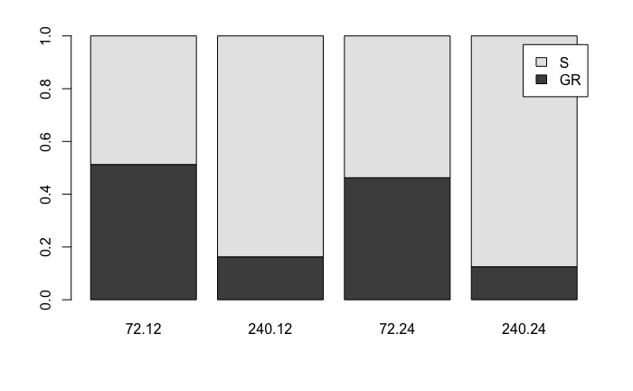

```r
table(sims$winner, interaction(sims$N, sims$memory)) %>% prop.table(2) %>% barplot(legend.text = c("GR", "S"))
```

```r
sims %>%
      group_by(b, periods, memory, G, N) %>%
      summarize(GR_wins = mean(winner == "GR")) %>%
      mutate(
        label = sprintf("b %s, pds %s, mem %s, G %s, N %s", b, periods, memory, G, N)
      ) -> summaries

# par(mar = c(5, 10, 1, 1))
# barplot(summaries$GR_wins, names.arg = summaries$label, horiz = TRUE, cex.names = .6, las = 2, border = NA, col = "blue")

ggplot(summaries, aes(y = GR_wins, x = factor(b), colour = factor(periods), shape = factor(memory))) + geom_point(alpha = .5, position = position_jitter(width = 0.1, height = 0)) + facet_grid(G ~ N, labeller = "label_both") + xlab("b")
```

[output not shown]

# Mechanisms

We’ll plot those last three correlations against which group won.

```r
f <- function(ggobj, var) {
  ggobj +
        geom_violin(aes_string(y = var)) +
        geom_point(aes_string(y = var), alpha = .2, color = 'brown', position = position_jitter(width = .05,
          height = 0))
}

p <- ggplot(sims, aes(x = winner))
f(p, "cor_prop_fit")
f(p, "cor_prop_reput")
f(p, "cor_reput_fit")
```

[output not shown]

```r
f(p, "generation") + facet_wrap(periods ~ N, labeller = "label_both")
```

[output not shown]